# Statistical challenges in single-cell RNA-seq analysis II

July 6, 2019

## Preview

1. Introduction to single-cell RNA-seq
2. **Quality control and Normalization**
3. Survey of downstream analysis methodology

## Getting that count matrix

- standard QC on raw reads (adapter/quality trim)
- mapping to reference genome - bulk tools appropriate (e.g. Salmon, STAR, RSEM, etc)
- count reads per transcript/gene - bulk tools appropriate (e.g. Subread)
- collapse UMIs & demultiplex (if applicable) -> [scPipe](http://bioconductor.org/packages/scPipe/)

[figure not shown]

## R: SingleCellExperiment Class

Amezquita et al. 2019 (https://doi.org/10.1101/590562)

## SingleCellExperiment Example

```
## class: SingleCellExperiment
## dim: 23918 192
## metadata(0):
## assays(1): counts
## rownames(23918): ENSMUSG00000103377 ENSMUSG00000103147 ...
##   ERCC-00171 CBFB-MYH11-mcherry
## rowData names(13): GeneLength ENSEMBL ... total_counts
##   log10_total_counts
## colnames(192): SLX-9555.N701_S502.C89V9ANXX.s_1.r_1
##   SLX-9555.N701_S503.C89V9ANXX.s_1.r_1 ...
##   SLX-11312.N712_S508.H5H5YBBXX.s_8.r_1
##   SLX-11312.N712_S517.H5H5YBBXX.s_8.r_1
## colData names(48): Plate Oncogene ...
##   pct_counts_in_top_500_features_ERCC PlateOnco
## reducedDimNames(0):
## spikeNames(1): ERCC
```

This SingleCellExperiment object has 23918 genes and 192 cells.

## Quality control metrics

- library size (= total number of reads/UMIs)
- number of expressed features / detection rate / dropout
- expression levels by gene
- proportion of reads mapped to spike-ins (if available) or MT genes
- [Droplet] remove empty droplets
- [Droplet] remove doublets

## Library size

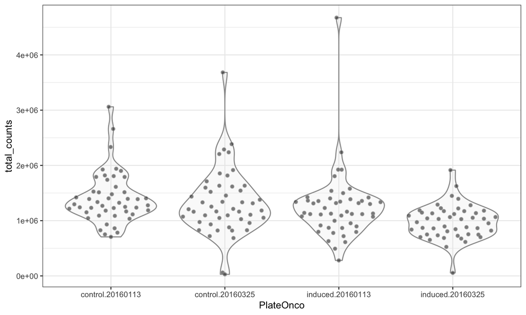

## Number of expressed features

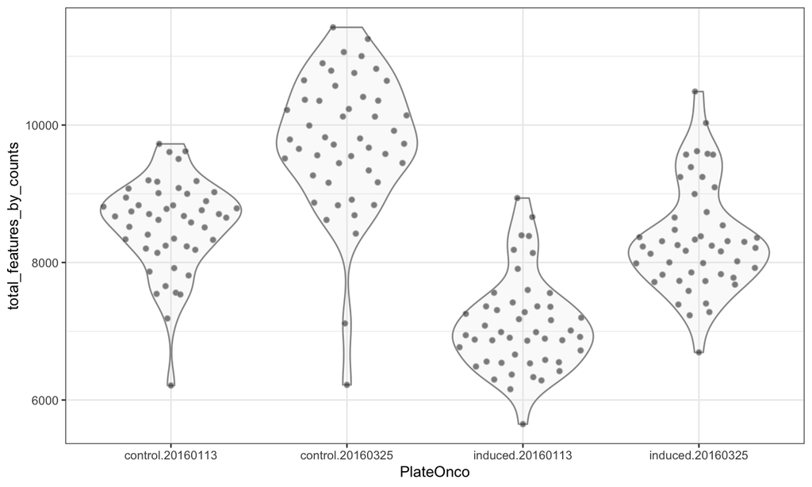

## Detection rate

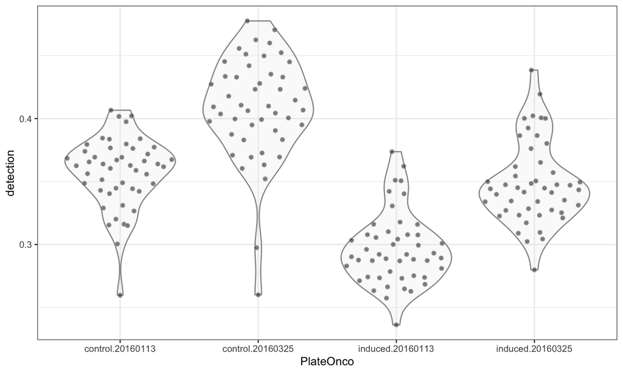

## Expression levels by gene - highest

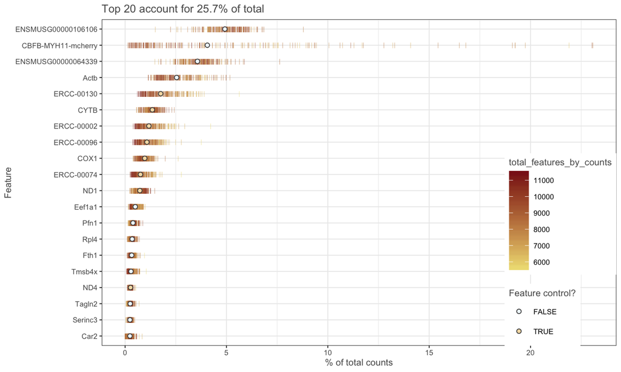

## Expression levels by gene - average

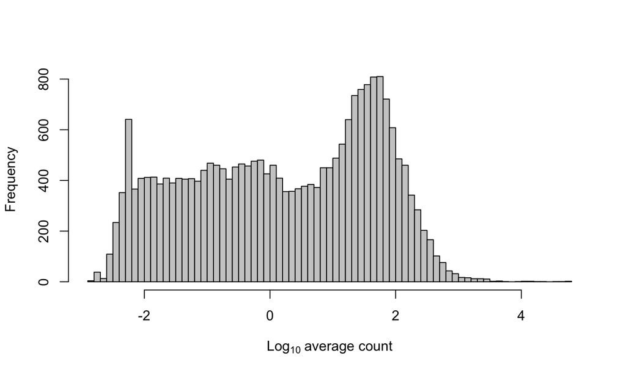

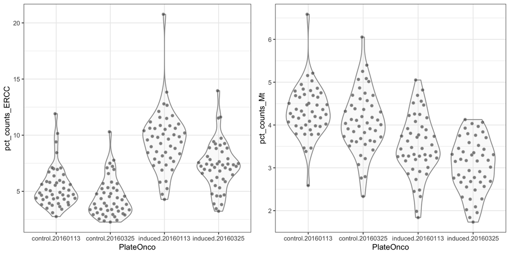

## [Droplet] Remove empty droplets

- Ideally each droplet contains one cell and one bead
- Process of adding cells (and beads) to droplets is stochastic, approiximated by a Poisson process: \[ P(k \text{ cells in a droplet}) = \frac{e^{-\lambda}\lambda^k}{k!}\]
- Typically cells are added at a low rate (\(\lambda\) << 1) to reduce the chance that a droplet contains multiple cells
- Unfortunately, this means many droplets contain zero cells
- Also unfortunately, reads still map to droplets with no cells

## Simple idea: empty droplets have fewest reads

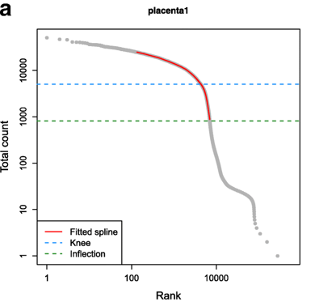

Lun et al. 2019, (https://doi.org/10.1186/s13059-019-1662-y)

- e.g. Quantile (CellRanger), Knee plot (Drop-seq)
- This risks removing cells with low biological material

## More sophisticated idea: EmptyDrops

- Lun et al. 2019, (https://doi.org/10.1186/s13059-019-1662-y)
- **Key idea**: expression profile of empty droplets \(\sim\) ambient RNA - Estimate ambient RNA profile by pooling across all cells/barcodes
- Ambient expression \(A_g\) for gene \(g\) is sum of counts \(y_{bg}\) over all barcodes \(b\): \[ A_g = \sum_b y_{bg} \]
- Counts for barcode \(b\) conditional on total counts for barcode \(b\) ~ Dirichlet-multinomial
  - allows for overdispersion (analogous to Gamma-poisson)
- Barcodes with strong deviations (permutation test on likelihood) are determined to be cells

## EmptyDrops rescues cells with few reads

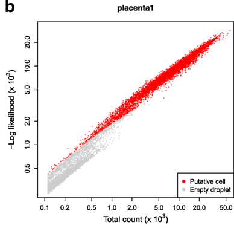

Lun et al. 2019, (https://doi.org/10.1186/s13059-019-1662-y)

## [Droplet] Remove doublets

- Even with the low cell rate, occasionally droplets contain two or more cells
- Can also happen in plate-based protocols (though rare) due to improper cell sorting/capture
- Simple idea: remove barcodes with especially high numbers of reads - works poorly with diverse cell types

## More sophisticated idea: cluster mixtures

- Bach et al. 2017 (https://doi.org/10.1038/s41467-017-02001-5)
- Key idea: remove cells that look like a mixture of two clusters

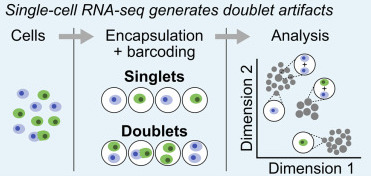

## Another sophisticated idea: simulate doublets

- Scrublet: Wolock, Lopez & Klein 2019 (https://doi.org/10.1016/j.cels.2018.11.005)
- DoubletFinder: McGinnis, Murrow & Gartner 2019 (https://doi.org/10.1016/j.cels.2019.03.003)
- Dahlin et al. 2018 (https://doi-org/10.1182/blood-2017-12-821413)
- Key idea: remove cells that look like simulated doublets

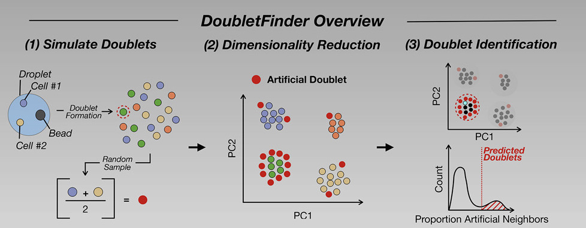

## Normalization

- Now that we’ve removed problematic cells, need to put counts on a comparable scale before downstream analysis
- Main factors to account for:
  - library size / sequencing depth
  - batch effects (known or unknown)

## Review: Sequence more, obtain more reads

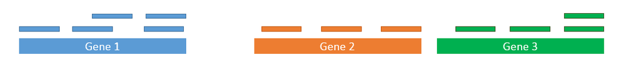

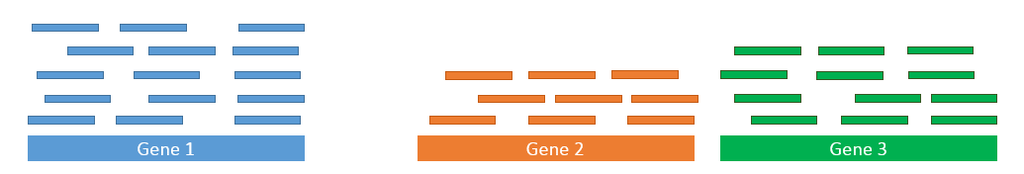

- DESeq2 library size factors use the median ratio method (Anders and Huber 2010 (https://doi.org/10.1186/gb-2010-11-10-r106)):

\[ \hat{s}_b = \text{median}_g \frac{y_{gb}}{(\prod_{j=1}^B y_{gj})^{1/B}} \] - assumes majority of genes are not differentially expressed

## Pooling

## SCnorm

## Adjusting for batch effects (equal cell composition)

## Adjusting for batch effects (unknown cell compositions)

## Transformation

## R tools for quality control and normalization

- [scater](http://bioconductor.org/packages/scater/): visualization, quality control (Bioconductor)
- [scran](http://bioconductor.org/packages/scran/): normalization, doublet detection, batch effect correction (Bioconductor)
- [SCnorm](http://bioconductor.org/packages/SCnorm/): normalization (Bioconductor)
- [DropletUtils](http://bioconductor.org/packages/DropletUtils/): removal of empty droplets (Bioconductor)
- [Seurat](https://satijalab.org/seurat/): normalization (CRAN)

[figure not shown]

[figure not shown]

[figure not shown]